# Session 13 · One More Thing: Principal Component and Factor Analyses

After the course · for self-study · not examined

Thierry Warin, PhD

HEC Montréal

## Outline · The hour ahead

1. Introduction
2. Principal Component Analysis
3. The Netflix’s Recommender System through a PCA
4. Factor analysis
5. FAMD: the wine data
6. Factor Analysis for Questionnaires

## What session 13 is for

### The mathematics

- Explain why PCA requires **standardised** inputs, and what happens if you forget
- Read a **scree plot** and defend the number of components retained
- Distinguish a **loading** from a **score**
- Say why a factor is identified only **up to rotation**

### The Python

- Compute components from the correlation matrix, and check against a library
- Plot the scree and the loadings, and label the axes with variance explained
- Rotate a factor solution and watch the fit stay identical

### The international business

- Build an index — competitiveness, openness, capability — from correlated indicators
- Defend the name you gave a component to a sceptical reader
- Say what a composite indicator hides as well as what it summarises

## Your Python so far

Everything you need to type is on one sheet — how to start Python in VS Codium on your platform, how to make a file and run it, the DataFrame basics, and every name from sessions 1 to 13, each with a line showing it in use.

> **[Python Cheatsheet · Session 13](https://warint.github.io/quantitative-methods/python-cheatsheet-13.pdf)** (PDF) · in the repository at `13-…/PYTHON-CHEATSHEET.pdf`

**One sheet per package, functions explained with pictures:** [pandas](https://warint.github.io/quantitative-methods/python-cheatsheets/pandas.pdf) · [NumPy](https://warint.github.io/quantitative-methods/python-cheatsheets/numpy.pdf) · [matplotlib](https://warint.github.io/quantitative-methods/python-cheatsheets/matplotlib.pdf) · [prince](https://warint.github.io/quantitative-methods/python-cheatsheets/prince.pdf) · [scikit-learn](https://warint.github.io/quantitative-methods/python-cheatsheets/sklearn.pdf) · [statsmodels](https://warint.github.io/quantitative-methods/python-cheatsheets/statsmodels.pdf)

Print it, or keep it open beside the editor. Nothing on it is examinable; all of it is assumed.

## Quote of the day

> "If you live 5 minutes away from Bill Gates, I bet you are rich."

## Introduction

## Where this session sits

- Map
- Concepts
- Types of ML
- Taxonomy

[figure not shown]

| Color (nm) | Alcohol (%) | Beer or Wine? |
| --- | --- | --- |
| 610 | 5 | Beer |
| 599 | 13 | Wine |
| 693 | 14 | Wine |

- Labels
- training / testing
- supervised / unsupervised (or self-supervised) / reinforcement learning
- System 1 (fast, intuitive) / System 2 (slow, analytical) (D. Kahneman)

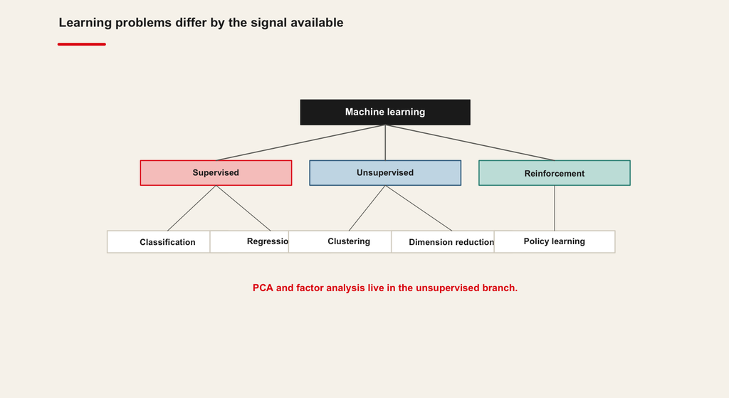

## The machine-learning workflow

- Steps
- Theory
- Practice
1. Gathering data
2. Pre-processing
3. Choosing a model
4. Training the model / K-fold cross-validation
5. Evaluation
6. Hyper-parameter tuning
7. Out-of-sample Prediction

[figure not shown]

[figure not shown]

## Regression or classification?

- Question
- Answer
- A set of principles that can be applied to regression or classification

> What is the difference between regression and classification models?
- **Regression** predicts a number: a price, a volume, a share.
- **Classification** predicts a category: default or not, beer or wine. A classifier draws a boundary between the classes.

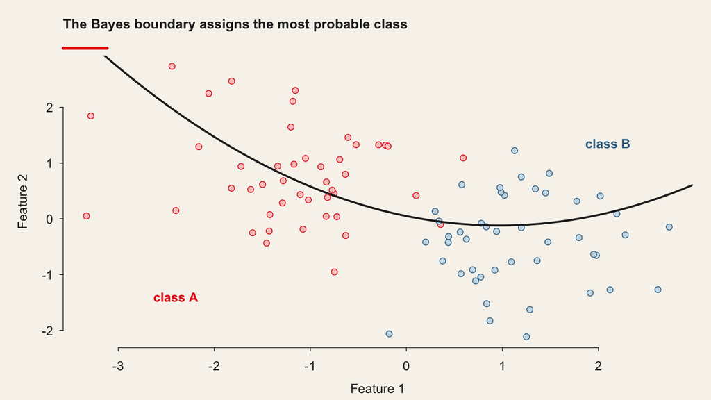

## Multivariate statistics

- Visual
- Definition
- Options

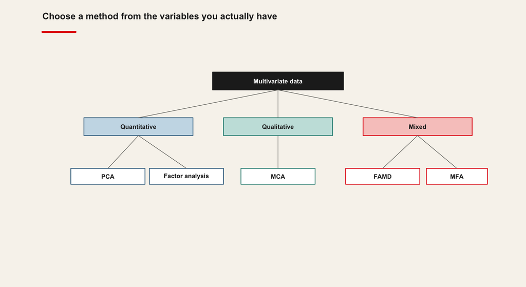

Multivariate Statistics is a group of statistical methods that focus on studying multiple variables together while focusing on the variation that those variables have in common.

> Definition: Multivariate Statistics deals with the treatment of data sets with a large number of dimensions.

Its goals are therefore different from supervised modeling, but also different from segmentation and clustering models.

There are many models in the family of Multivariate Statistics.

1. PCA
1. Factor Analysis

## Principal Component Analysis

## Why PCA?

- Issues
- Solution
- Modern datasets often have a very large number of variables. This makes it **difficult to inspect each of the variables individually**, due to the practical fact that the human mind cannot easily digest data on such a large scale.
- When a dataset contains a large number of variables, there is often a **serious amount of overlap between those variables**.
- The components that are found by **PCA are ordered from the highest information content to the lowest information content**.

PCA is a statistical method that allows you to “regroup” your variables into a smaller number of variables, called **components**.

This regrouping is done based on variation that is common to multiple variables.

Interesting book: https://shainarace.github.io/LinearAlgebra/pca.html

## What PCA does

- Goal
- Visuals

The goal of PCA is to regroup variables in such a way that the first (newly created) component contains a maximum of variation.

- The second component contains the second-largest amount of variation, etc.

The last component logically contains the smallest amount of variation.

Thanks to this ordering of components, it is made possible **to retain only a few of the newly created components, while still retaining a maximum amount of variation**.

> We can then use the components rather than the original variables for data exploration.

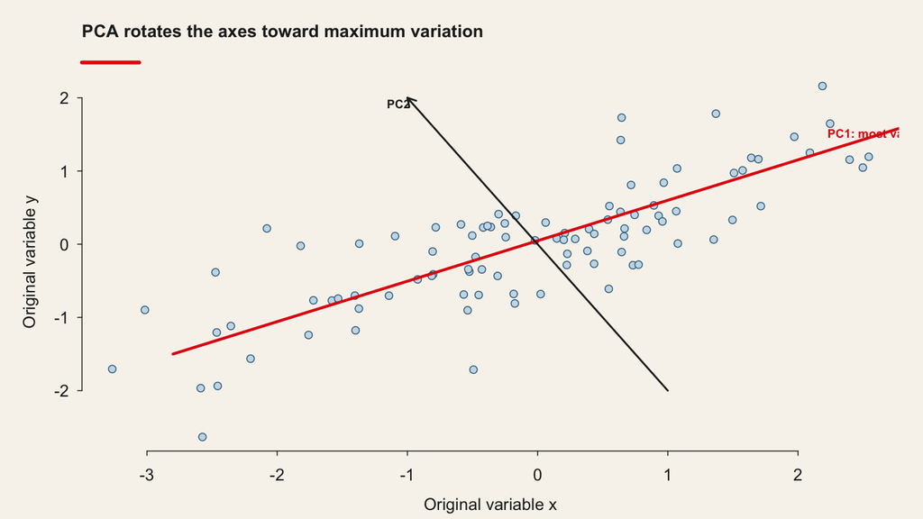

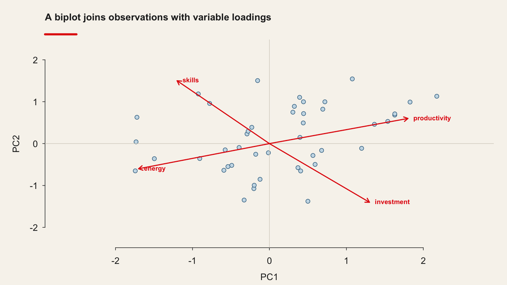

## Mathematical Model — Maximize variance of the new components

- Variance
- Maximize
- Conditions

The mathematical definition of the PCA problem is to find a **linear combination of the original variables with maximum variance**.

This means that we are going to create a (new) component. Let’s call it \(z\). This z is going to be computed based on our original variables \((X_1, X_2, …)\) multiplied by a weight for each of our variables \((u_1, u_2, …)\).

This can be written as \(z = Xu\).

[We apply it to cross-section data. For time-series cross-section data, we can use the superPCA package. Not exam material!]

The mathematical goal is to find the values for \(u\) that will maximize the variance of \(z\), with a constraint of unit length on \(u\).

> This problem is mathematically called a constrained optimization using Lagrange Multiplier, but in practice, we use computers to do the whole PCA operation at once.

This can also be described as applying matrix decomposition to the correlation matrix of the original variables.

PCA is efficient in finding the components that maximize variance.

This is great if we are interested in **reducing the number of variables while keeping a maximum of variance**.

**Sometimes, however, we are not purely interested in maximizing variance: we might want to give the most useful interpretations to our newly defined dimensions.**

And this is not always easiest with the solution found by a PCA.

> We can then apply Factor Analysis: an alternative to PCA that has a little bit more flexibility.
- PCA only works with numeric data
- Categorical data must be encoded as numeric data (e.g. "one-hot encoding" = creating dummies from categories, `pd.get_dummies`)
- Numeric data must be scaled (otherwise your PCA will be misleading)

## The Netflix's Recommender System through a PCA

## Step 1: Collecting the data

These files contain metadata for all 45,000 movies listed in the Full MovieLens Dataset. The dataset consists of movies released on or before July 2017.

Data points include cast, crew, plot keywords, budget, revenue, posters, release dates, languages, production companies, countries, TMDB vote counts and vote averages.

```python
import qmib
import numpy as np
import pandas as pd

movies = qmib.load("movies")

# Keep the numeric columns and drop rows with holes
df = movies[["budget", "popularity", "revenue", "runtime",
             "vote_average", "vote_count"]].dropna()
df.head()
```

|  | budget | popularity | revenue | runtime | vote_average | vote_count |
| --- | --- | --- | --- | --- | --- | --- |
| 0 | 30000000.0 | 21.946943 | 373554033.0 | 81.0 | 7.7 | 5415.0 |
| 1 | 65000000.0 | 17.015539 | 262797249.0 | 104.0 | 6.9 | 2413.0 |
| 2 | 0.0 | 11.712900 | 0.0 | 101.0 | 6.5 | 92.0 |
| 3 | 16000000.0 | 3.859495 | 81452156.0 | 127.0 | 6.1 | 34.0 |
| 4 | 0.0 | 8.387519 | 76578911.0 | 106.0 | 5.7 | 173.0 |

## Step 2: Computing the principal components

- Eigenvalues
- Scree plot

```python
from sklearn.decomposition import PCA
from sklearn.preprocessing import StandardScaler

# PCA is scale-dependent: standardise first, always.
Z = StandardScaler().fit_transform(df)
res_pca = PCA().fit(Z)

# Eigenvalues and the variance each component explains
eig = pd.DataFrame({
    "eigenvalue": res_pca.explained_variance_,
    "pct_variance": res_pca.explained_variance_ratio_ * 100,
    "cumulative_pct": np.cumsum(res_pca.explained_variance_ratio_) * 100,
}, index=[f"PC{i+1}" for i in range(len(res_pca.explained_variance_))])
print(eig.round(2))
```

```
     eigenvalue  pct_variance  cumulative_pct
PC1        2.96         49.41           49.41
PC2        1.11         18.57           67.97
PC3        0.85         14.13           82.10
PC4        0.60          9.96           92.06
PC5        0.31          5.20           97.26
PC6        0.16          2.74          100.00
```

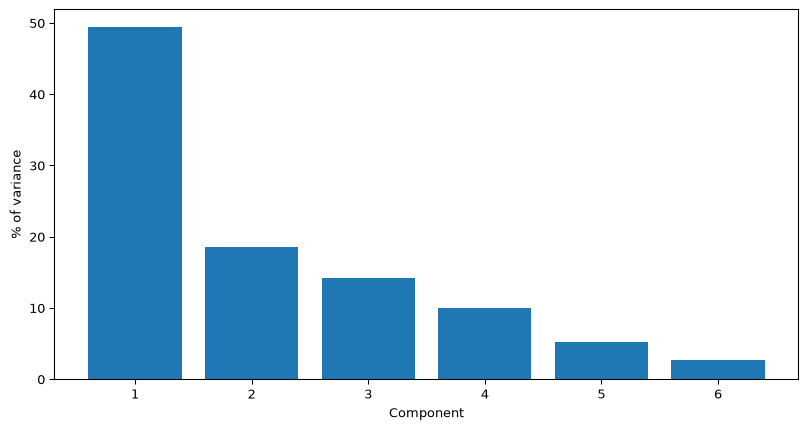

```python
import matplotlib.pyplot as plt

# Scree plot: where does the curve flatten?
plt.bar(range(1, len(res_pca.explained_variance_ratio_) + 1),
        res_pca.explained_variance_ratio_ * 100)
plt.xlabel("Component"); plt.ylabel("% of variance")
plt.show()
```

## Step 3: Which variables contribute to the principal components?

- Loadings
- Contributions

```python
# The loadings: how each variable relates to each component
loadings = pd.DataFrame(
    res_pca.components_.T * np.sqrt(res_pca.explained_variance_),
    index=df.columns, columns=[f"PC{i+1}" for i in range(res_pca.n_components_)])
print(loadings.round(3))
```

```
                PC1    PC2    PC3    PC4    PC5    PC6
budget        0.852 -0.133  0.074 -0.271  0.403 -0.121
popularity    0.716  0.064 -0.102  0.679  0.106  0.023
revenue       0.910 -0.160  0.013 -0.191 -0.106  0.314
runtime       0.222  0.704  0.674 -0.004 -0.028  0.006
vote_average  0.201  0.748 -0.614 -0.151  0.017  0.007
vote_count    0.899 -0.104 -0.032 -0.056 -0.356 -0.224
```

```python
# Contribution of each variable to each component, in percent
contrib = (loadings ** 2)
contrib = contrib / contrib.sum() * 100
print(contrib.round(2))
```

```
                PC1    PC2    PC3    PC4    PC5    PC6
budget        24.50   1.59   0.65  12.33  51.95   8.98
popularity    17.29   0.37   1.22  77.22   3.58   0.32
revenue       27.93   2.30   0.02   6.10   3.58  60.06
runtime        1.66  44.54  53.52   0.00   0.25   0.02
vote_average   1.36  50.24  44.45   3.83   0.09   0.03
vote_count    27.27   0.97   0.12   0.52  40.54  30.59
```

## Step 3 (cont.): The variables, drawn

- Variable plot
- Contributions to PC1
- Contributions to PC2

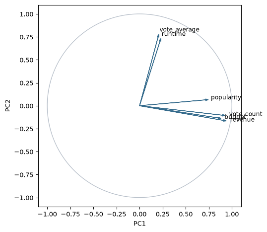

```python
# Variable plot: arrows on the unit circle
fig, ax = plt.subplots(figsize=(5.5, 5.5))
for name, (x, y) in loadings[["PC1", "PC2"]].iterrows():
    ax.arrow(0, 0, x, y, head_width=.02, color="#356B8C")
    ax.text(x * 1.08, y * 1.08, name, fontsize=9)
ax.add_patch(plt.Circle((0, 0), 1, fill=False, color="#B8C0CA"))
ax.set_xlim(-1.1, 1.1); ax.set_ylim(-1.1, 1.1)
ax.set_xlabel("PC1"); ax.set_ylabel("PC2")
plt.show()
```

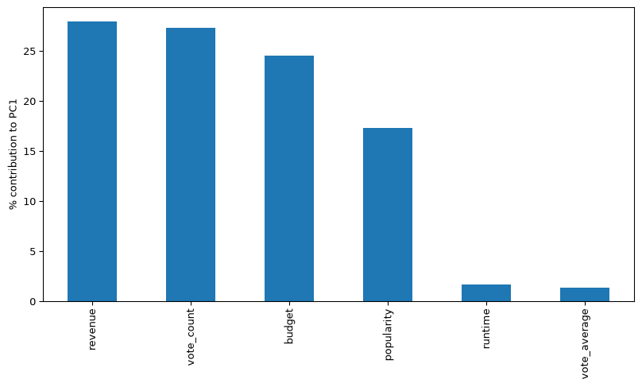

```python
contrib["PC1"].sort_values(ascending=False).head(10).plot.bar()
plt.ylabel("% contribution to PC1"); plt.show()
```

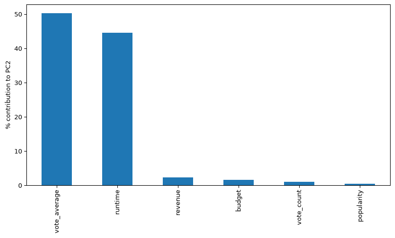

```python
contrib["PC2"].sort_values(ascending=False).head(10).plot.bar()
plt.ylabel("% contribution to PC2"); plt.show()
```

## Step 4: Where each film sits — the scores

- Summary
- First films

```python
# The scores: where each film sits in the new coordinate system
scores = pd.DataFrame(res_pca.transform(Z)[:, :5],
                      columns=[f"PC{i+1}" for i in range(5)])
scores.describe().round(3)
```

|  | PC1 | PC2 | PC3 | PC4 | PC5 |
| --- | --- | --- | --- | --- | --- |
| count | 45203.000 | 45203.000 | 45203.000 | 45203.000 | 45203.000 |
| mean | -0.000 | 0.000 | 0.000 | 0.000 | -0.000 |
| std | 1.722 | 1.055 | 0.921 | 0.773 | 0.559 |
| min | -1.193 | -7.012 | -10.076 | -9.876 | -13.220 |
| 25% | -0.524 | -0.386 | -0.409 | -0.260 | -0.094 |
| 50% | -0.379 | 0.139 | -0.041 | -0.098 | -0.059 |
| 75% | -0.099 | 0.572 | 0.338 | 0.236 | 0.002 |
| max | 54.969 | 21.086 | 21.366 | 72.961 | 10.687 |

```python
scores.head().round(3)
```

|  | PC1 | PC2 | PC3 | PC4 | PC5 |
| --- | --- | --- | --- | --- | --- |
| 0 | 10.716 | -1.364 | -1.501 | -0.114 | -6.208 |
| 1 | 7.305 | -0.704 | -0.341 | -0.596 | -0.758 |
| 2 | 0.450 | 0.592 | -0.355 | 1.322 | 0.163 |
| 3 | 1.030 | 0.521 | 0.521 | -0.412 | 0.371 |
| 4 | 0.902 | 0.152 | 0.092 | 0.613 | -0.291 |

## Step 4 (cont.): The films, drawn

- Individuals
- Biplot

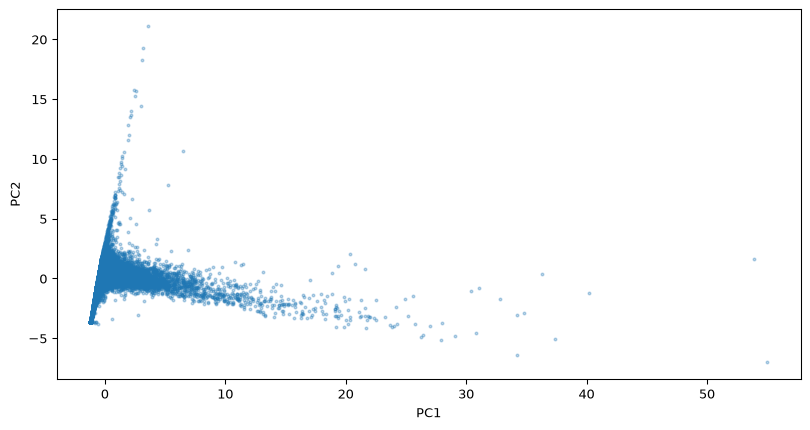

```python
# Individuals plotted on the first two components
plt.scatter(scores["PC1"], scores["PC2"], s=4, alpha=.3)
plt.xlabel("PC1"); plt.ylabel("PC2")
plt.show()
```

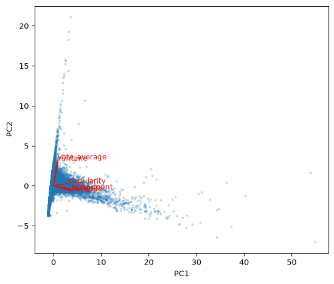

```python
# Biplot: individuals as points, variables as arrows
fig, ax = plt.subplots(figsize=(6.5, 5.5))
ax.scatter(scores["PC1"], scores["PC2"], s=4, alpha=.2)
scale = 4
for name, (x, y) in loadings[["PC1", "PC2"]].iterrows():
    ax.arrow(0, 0, x * scale, y * scale, head_width=.08, color="#E3120B")
    ax.text(x * scale * 1.1, y * scale * 1.1, name, fontsize=9, color="#E3120B")
ax.set_xlabel("PC1"); ax.set_ylabel("PC2")
plt.show()
```

## Factor analysis

## What factor analysis assumes

- Definition
- Common Factor Model

Just like PCA, Factor Analysis is also a model that allows reducing information in a larger number of variables into a smaller number of variables. In Factor Analysis we call those **latent variables**.

> Definition: Factor Analysis tries to find latent variables that make sense to us. We can rotate the solution until we find latent variables that have a clear interpretation and “make sense”.

Factor Analysis is based on a model called the common factor model. It starts from the principle that there a certain number of factors in a data set, and that each of the measured variables captures a part of one or more of those factors.

We could imagine having students who are overall good in languages, but bad in technical subjects. In this case, we could try to find a latent variable for language ability and a second latent variable for technical ability.

We now have latent variables that measure the general ability of a student for Language and Technical subjects. But it would still be possible that some students are great at languages overall, but that they are just bad at German.

This is why the **Common Factor Model** has specific factors: they measure the impact of one specific measured variable on the measured variable.

> We could describe it as “Ability for learning German while taking into account the general ability for learning languages”.

## The factor model

- Latent variables
- Mathematics

Where the PCA model is more of a pragmatic approach, in Factor Analysis we are hypothesizing that latent variables exist.

In a case with two latent variables, we can compute our original variables \(X\) by attributing one part of its variation to our first common latent variable (let’s call it \(k_1\)), part to the second common latent variable (\(k_2\)), and part to a specific factor (specific to this variable; called \(d\)).

In a case with 4 original variables, the Factor Analysis model would be as follows:

$$X_1 = c_{11} * k_1 + c_{12} * k_2 + d_1$$

$$X_2 = c_{21} * k_1 + c_{22} * k_2 + d_2$$

$$X_3 = c_{31} * k_1 + c_{32} * k_2 + d_3$$

$$X_4 = c_{41} * k_1 + c_{42} * k_2 + d_4$$

\(c\) are each coefficient of the coefficient matrix, which are the values that we need to estimate.

## FAMD: the wine data

## Fitting FAMD

- Fit
- Eigenvalues

```python
# FAMD — factor analysis of mixed (numeric and categorical) data.
import prince

wine = qmib.load("redwines")

# FAMD wants the mix: the chemistry as numbers, the verdict as a category.
# `good` is dropped once it has become a label, or the same information enters
# twice and the first dimension is simply that duplication.
wine["quality_label"] = np.where(wine["good"] == 1, "good", "ordinary")
wine = wine.drop(columns=["good"])

famd = prince.FAMD(n_components=5, random_state=0).fit(wine)
```

```python
# Eigenvalues of the FAMD dimensions
print(famd.eigenvalues_summary)
```

```
          eigenvalue % of variance % of variance (cumulative)
component
0              2.155        23.95%                     23.95%
1              1.861        20.68%                     44.63%
2              1.218        13.53%                     58.15%
3              1.140        12.67%                     70.82%
4              0.857         9.52%                     80.34%
```